# IPL_PlayerPricePred_Feature_Importance_Group_8

### Group 8 members:

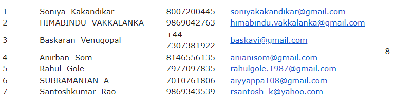

## Overview: Devleop a regression model (using linear regression) and identify the factors which influence the price/cost of players.

### Table of content:

#### 1. Target variable distribution

#### 2. EDA

#### 2.1. Bivariate analysis

#### 2.2. Insights from the data

#### 3. Model data preperation

#### 4. Linear regression

#### 4.1. Linear regression conclusion

#### 5. Decision tree

#### 5.1. Decision tree feature importance, permutation importance & SHAP values ranking

#### 6. Random forest

#### 6.1. Random forest feature importance, permutation importance & SHAP values ranking

### 7. Conclusion

```python
import pandas as pd
import numpy as np
import warnings
warnings.filterwarnings("ignore")
import plotly.express as px
from mlxtend.preprocessing import minmax_scaling

from sklearn.model_selection import train_test_split

import sympy

from statsmodels.regression.linear_model import OLS
from statsmodels.tools.tools import add_constant
import plotly.graph_objects as go
from IPython.display import HTML, display, Markdown, clear_output

import statsmodels.api as sm

import numpy as np
from sklearn.preprocessing import StandardScaler
from sklearn.pipeline import Pipeline
from sklearn.model_selection import train_test_split, GridSearchCV
from sklearn.linear_model import Lasso

from sklearn.ensemble import RandomForestRegressor
import matplotlib.pyplot as plt
import seaborn as sns

from sklearn.tree import DecisionTreeRegressor

import eli5
from eli5.sklearn import PermutationImportance
```

```python
ipl=pd.read_csv('ipl.csv')
ipl=ipl.rename(columns=lambda s: s.replace(" ", ""))
ipl=ipl.rename(columns=lambda s: s.replace("-", "_"))
ipl=ipl.rename(columns=lambda s: s.replace(".", "_"))

ipl.columns
```

```
Index(['Sl_NO_', 'PLAYERNAME', 'AGE', 'COUNTRY', 'TEAM', 'PLAYINGROLE',
       'T_RUNS', 'T_WKTS', 'ODI_RUNS_S', 'ODI_SR_B', 'ODI_WKTS', 'ODI_SR_BL',
       'CAPTAINCYEXP', 'RUNS_S', 'HS', 'AVE', 'SR_B', 'SIXERS', 'RUNS_C',
       'WKTS', 'AVE_BL', 'ECON', 'SR_BL', 'AUCTIONYEAR', 'BASEPRICE',
       'SOLDPRICE'],
      dtype='object')
```

### Target variable distribution

```python
ipl_dist=px.histogram(ipl, x='SOLDPRICE')
ipl_dist.update_layout(autosize=False, width=500, height=400)
ipl_dist.show()
```

[interactive chart not shown]

```python
ipl.columns
```

```
Index(['Sl_NO_', 'PLAYERNAME', 'AGE', 'COUNTRY', 'TEAM', 'PLAYINGROLE',
       'T_RUNS', 'T_WKTS', 'ODI_RUNS_S', 'ODI_SR_B', 'ODI_WKTS', 'ODI_SR_BL',
       'CAPTAINCYEXP', 'RUNS_S', 'HS', 'AVE', 'SR_B', 'SIXERS', 'RUNS_C',
       'WKTS', 'AVE_BL', 'ECON', 'SR_BL', 'AUCTIONYEAR', 'BASEPRICE',
       'SOLDPRICE'],
      dtype='object')
```

## Exploratory data analysis

#### Created High, Medium, Low buckets on the few selected list of continuous column values and comapred with the SOLDPRICE target variable. (Also created high,medim,low buckets on sold price)

```python
ipl_df=ipl[['AGE', 'COUNTRY', 'PLAYINGROLE','ODI_SR_B','SIXERS', 'RUNS_C','WKTS', 'BASEPRICE','SOLDPRICE']]
ipl_df

cols=[]
for i in list(ipl_df.columns):
    if ipl_df[i].dtypes!='O':
        cols.append(i)
cols.remove('AGE')
for i in cols:
    ipl_df[i]=pd.qcut(ipl_df[i],q=3,labels=['low','med','high'])
ipl_df['AGE']=ipl_df['AGE'].astype(str)
ipl_df
# base price,sixes,run_c,odi strike rate_b,age,country,playing role,wickets
```

|  | AGE | COUNTRY | PLAYINGROLE | ODI_SR_B | SIXERS | RUNS_C | WKTS | BASEPRICE | SOLDPRICE |
| --- | --- | --- | --- | --- | --- | --- | --- | --- | --- |
| 0 | 2 | SA | Allrounder | low | low | med | med | low | low |
| 1 | 2 | BAN | Bowler | low | low | low | low | low | low |
| 2 | 2 | IND | Bowler | med | med | high | high | med | med |
| 3 | 1 | IND | Bowler | high | low | high | high | low | high |
| 4 | 2 | IND | Batsman | low | high | low | low | low | high |
| ... | ... | ... | ... | ... | ... | ... | ... | ... | ... |
| 125 | 2 | IND | Batsman | low | med | low | low | low | high |
| 126 | 2 | PAK | Batsman | med | low | low | low | high | low |
| 127 | 2 | IND | Batsman | high | high | high | high | high | high |
| 128 | 2 | IND | Bowler | med | low | high | high | med | med |
| 129 | 2 | SL | Bowler | high | low | med | med | low | low |

130 rows × 9 columns

### Bivariate analysis

```python
def bivar_eda(df,col1,col2):
    df_bar=df.groupby([col1,col2]).size().reset_index().rename({0:'player_count'},axis=1)
    df_bar['player_count_%']=df_bar['player_count']*100/df_bar['player_count'].sum()
    df_bar['player_count_%']=df_bar['player_count_%'].apply(lambda x:str(np.round(x,2))+'%')
    bar_plot=px.bar(df_bar,x=col2,y='player_count',color=col1,text='player_count_%',
                    title='Distribution for buckets of '+col2+' across different '+col1)

    bar_plot.update_layout(
                        autosize=False,
                        width=600,
                        height=450)
    bar_plot.show()


col_eda=list(ipl_df.columns)
col_eda.remove("SOLDPRICE")
col_eda
for i in col_eda:
    bivar_eda(ipl_df,i,'SOLDPRICE')
```

[interactive chart not shown]

### Insights:

#### Approx. 17% of Low ODI Strike rate batsman are sold at lower prices, where as 17% high Strike rate batsman are sold at higher price, also 16.15% medium strike rate batsman are sold at medium price.

#### Approx. 18% of Low six hitters are sold at lower prices, where as 18.46% high Strike rate batsman are sold at higher price, the medium price bucket is almost evenly distributed.

#### 13% of Low run scorers are sold at lower prices, whereas medium and high run scorer contributes to approx. 32% and has a higher possibility/or is getting sold at higher price range.

#### 13% of Low wicket takers are sold at lower prices, whereas medium and high wicket takers contributes to approx. 31% and has a higher possibility/or is getting sold at higher price range.

#### Approx. 20-30% players with low base price has low sold price, whereas 15% players with high base price are sold at high sold price.

#### Young age group players are generally sold at higher sold price (7%)

#### Indian players are preferred more (18%) are sold at higher sold price bucket.

### Model data preperation:

```python
ipl_model=ipl[['AGE', 'COUNTRY', 'TEAM', 'PLAYINGROLE',
               'T_RUNS', 'T_WKTS', 'ODI_RUNS_S', 'ODI_SR_B', 'ODI_WKTS', 'ODI_SR_BL',
               'CAPTAINCYEXP', 'RUNS_S', 'HS', 'AVE', 'SR_B', 'SIXERS', 'RUNS_C',
               'WKTS', 'AVE_BL', 'ECON', 'SR_BL', 'BASEPRICE',
               'SOLDPRICE']]

ipl_model_lab=ipl_model[['AGE']]

ipl_model_dum=ipl_model[['COUNTRY', 'TEAM', 'PLAYINGROLE']]
ipl_model_dum_enc=pd.get_dummies(ipl_model_dum, columns=ipl_model_dum.columns, drop_first=True)

ipl_model_scale=ipl_model[['T_RUNS', 'T_WKTS', 'ODI_RUNS_S', 'ODI_SR_B', 'ODI_WKTS', 'ODI_SR_BL',
                           'CAPTAINCYEXP', 'RUNS_S', 'HS', 'AVE', 'SR_B', 'SIXERS', 'RUNS_C',
                           'WKTS', 'AVE_BL', 'ECON', 'SR_BL', 'BASEPRICE']]

ipl_model_scale_minmax=minmax_scaling(ipl_model_scale, columns=ipl_model_scale.columns)

ipl_model_1=pd.merge(ipl_model_lab, ipl_model_dum_enc, left_index=True, right_index=True)

ipl_model_f=pd.merge(ipl_model_1, ipl_model_scale_minmax, left_index=True, right_index=True)

ipl_model_y=ipl_model[['SOLDPRICE']]

ipl_model_fy=pd.merge(ipl_model_f, ipl_model_y, left_index=True, right_index=True)

ipl_model_fy
```

|  | AGE | COUNTRY_BAN | COUNTRY_ENG | COUNTRY_IND | COUNTRY_NZ | COUNTRY_PAK | COUNTRY_SA | COUNTRY_SL | COUNTRY_WI | COUNTRY_ZIM | ... | AVE | SR_B | SIXERS | RUNS_C | WKTS | AVE_BL | ECON | SR_BL | BASEPRICE | SOLDPRICE |
| --- | --- | --- | --- | --- | --- | --- | --- | --- | --- | --- | --- | --- | --- | --- | --- | --- | --- | --- | --- | --- | --- |
| 0 | 2 | 0 | 0 | 0 | 0 | 0 | 1 | 0 | 0 | 0 | ... | 0.000000 | 0.000000 | 0.000000 | 0.155443 | 0.043478 | 0.162074 | 0.233535 | 0.139022 | 0.022556 | 50000 |
| 1 | 2 | 1 | 0 | 0 | 0 | 0 | 0 | 0 | 0 | 0 | ... | 0.000000 | 0.000000 | 0.000000 | 0.014684 | 0.000000 | 0.000000 | 0.380478 | 0.000000 | 0.022556 | 50000 |
| 2 | 2 | 0 | 0 | 1 | 0 | 0 | 0 | 0 | 0 | 0 | ... | 0.370385 | 0.513865 | 0.038760 | 0.536203 | 0.084058 | 0.289153 | 0.231173 | 0.248503 | 0.135338 | 350000 |
| 3 | 1 | 0 | 0 | 1 | 0 | 0 | 0 | 0 | 0 | 0 | ... | 0.115745 | 0.324090 | 0.000000 | 0.569620 | 0.142029 | 0.181789 | 0.163474 | 0.220958 | 0.060150 | 850000 |
| 4 | 2 | 0 | 0 | 1 | 0 | 0 | 0 | 0 | 0 | 0 | ... | 0.657154 | 0.512591 | 0.217054 | 0.000000 | 0.000000 | 0.000000 | 0.000000 | 0.000000 | 0.060150 | 800000 |
| ... | ... | ... | ... | ... | ... | ... | ... | ... | ... | ... | ... | ... | ... | ... | ... | ... | ... | ... | ... | ... | ... |
| 125 | 2 | 0 | 0 | 1 | 0 | 0 | 0 | 0 | 0 | 0 | ... | 0.195570 | 0.533526 | 0.015504 | 0.000000 | 0.000000 | 0.000000 | 0.000000 | 0.000000 | 0.022556 | 750000 |
| 126 | 2 | 0 | 0 | 0 | 0 | 1 | 0 | 0 | 0 | 0 | ... | 0.059868 | 0.181961 | 0.000000 | 0.000000 | 0.000000 | 0.000000 | 0.000000 | 0.000000 | 0.154135 | 225000 |
| 127 | 2 | 0 | 0 | 1 | 0 | 0 | 0 | 0 | 0 | 0 | ... | 0.525244 | 0.560024 | 0.519380 | 0.288101 | 0.066667 | 0.195883 | 0.184204 | 0.210878 | 0.285714 | 1800000 |
| 128 | 2 | 0 | 0 | 1 | 0 | 0 | 0 | 0 | 0 | 0 | ... | 0.197565 | 0.389273 | 0.007752 | 0.902785 | 0.188406 | 0.217181 | 0.203359 | 0.212176 | 0.135338 | 450000 |
| 129 | 2 | 0 | 0 | 0 | 0 | 0 | 0 | 1 | 0 | 0 | ... | 0.219517 | 0.519003 | 0.000000 | 0.050127 | 0.005797 | 0.391924 | 0.236158 | 0.329341 | 0.060150 | 110000 |

130 rows × 48 columns

```python
## Target variable selection and split %
target_var='SOLDPRICE'
# split_percentage=15

# ## X and y seperation
#split_perc=split_percentage/100
X=ipl_model_fy.loc[:,ipl_model_fy.columns]
y=ipl_model_fy[target_var]
X=X.drop(target_var,axis=1)

## Splitting the data for modelling (without oversampling)
# x_train,x_valid,y_train,y_valid=train_test_split(X,y,test_size=split_perc,random_state=0)

# print("Training-Validation Split Percentage:{split} %".format(split=int((1-split_perc)*100)))
# print("Total Observation:{obs}".format(obs=X.shape[0]))
# print("Training Observation:{train_obs}".format(train_obs=x_train.shape[0]))
# print("Validation Observation:{valid_obs}".format(valid_obs=x_valid.shape[0]))
```

#### Data pre processing - linear dependency, multi colinearity and variability check

```python
def linear_dependency(x_train):
    feature_space=x_train.loc[:,x_train.columns!=target_var]
    reduced_form,inds=sympy.Matrix(feature_space.values).rref()
    indep_features=[feature_space.columns.tolist()[i] for i in inds]
    collinear_features=[item for item in feature_space.columns if item not in set(indep_features)]

    if len(collinear_features)>0:
            print("\nFeatures causing linear dependency:{ld}".format(ld=" || ".join(collinear_features)))
            print("These variables will be removed which are causing linear dependency")
            x_train_processed=x_train[indep_features]
            print("Data contains {} rows and {} columns".format(x_train_processed.shape[0],x_train_processed_shape[1]))
            display(x_train_processed.dtypes)
    else:
        print("No linear dependent columns")
        x_train_processed=x_train.copy()

    return x_train_processed


x_train=linear_dependency(X)
```

```
No linear dependent columns
```

```python
def multi_collinear(x_train_processed):
    truncate_value=10
    exog_df=x_train_processed.loc[:,x_train_processed.columns!=target_var]
    exog_df=x_train_processed.copy()

    exog_df=add_constant(exog_df)
    vifs=pd.Series([1/(1.-OLS(exog_df[col].values,
                              exog_df.loc[:,exog_df.columns!=col].values).fit().rsquared) for col in exog_df],
                   index=exog_df.columns,
                   name='VIF')

    vifs=pd.DataFrame(vifs)
    vifs.drop('const',axis=0,inplace=True)
    vifs=vifs['VIF'].where(vifs['VIF']<=truncate_value,truncate_value)
    vifs=pd.DataFrame(vifs)
    vifs_df=vifs.sort_values(by=['VIF'],ascending=True)

    vifs_df['colors']=np.where(vifs_df.VIF<=5,'yellowgreen',
                                 np.where((vifs_df.VIF>5) & (vifs_df.VIF<=10),'steelblue','tomato'))

    Layout=go.Layout(title="VIF plot", xaxis=dict(title='VIF'),yaxis=dict(title='Features'))
    fig=go.Figure(go.Bar(x=vifs_df.VIF,y=vifs_df.index.tolist(),
                         orientation='h',marker_color=vifs_df['colors']),layout=Layout)
    fig.add_shape(type="line",x0=5,y0=0,x1=5,y1=len(vifs_df.index.tolist()),
                  line=dict(color="midnightblue",width=2,dash="dot"))
    fig.add_shape(type="line",x0=10,y0=0,x1=10,y1=len(vifs_df.index.tolist()),
                  line=dict(color="midnightblue",width=2,dash="dot"))

    fig.update_layout(width=800,height=800)
    fig.show(config={'displaylogo':False})
    return vifs

vifs=multi_collinear(x_train)


def multi_col_vars(vifs):
    multicorr_vars=vifs['VIF'].loc[lambda x:x>=10].index.tolist()
    col_to_drop=multicorr_vars

    if col_to_drop==[]:
        #clear_output()
        print("No columns were dropped")
    else:
        #clear_output()
        x_train.drop(col_to_drop,axis=1,inplace=True)
        display(Markdown('Successfully dropped:{}'.format(",".join(col_to_drop))))

        display(x_train.dtypes)
    return x_train


x_train=multi_col_vars(vifs)

x_train
```

[interactive chart not shown]

Successfully dropped:ODI_RUNS_S,ODI_WKTS,RUNS_S,HS,AVE,AVE_BL,SR_BL

```
AGE                        int64
COUNTRY_BAN                uint8
COUNTRY_ENG                uint8
COUNTRY_IND                uint8
COUNTRY_NZ                 uint8
COUNTRY_PAK                uint8
COUNTRY_SA                 uint8
COUNTRY_SL                 uint8
COUNTRY_WI                 uint8
COUNTRY_ZIM                uint8
TEAM_CSK+                  uint8
TEAM_DC                    uint8
TEAM_DC+                   uint8
TEAM_DD                    uint8
TEAM_DD+                   uint8
TEAM_KKR                   uint8
TEAM_KKR+                  uint8
TEAM_KXI+                  uint8
TEAM_KXIP                  uint8
TEAM_KXIP+                 uint8
TEAM_MI                    uint8
TEAM_MI+                   uint8
TEAM_RCB                   uint8
TEAM_RCB+                  uint8
TEAM_RR                    uint8
TEAM_RR+                   uint8
PLAYINGROLE_Batsman        uint8
PLAYINGROLE_Bowler         uint8
PLAYINGROLE_W. Keeper      uint8
T_RUNS                   float64
T_WKTS                   float64
ODI_SR_B                 float64
ODI_SR_BL                float64
CAPTAINCYEXP             float64
SR_B                     float64
SIXERS                   float64
RUNS_C                   float64
WKTS                     float64
ECON                     float64
BASEPRICE                float64
dtype: object
```

|  | AGE | COUNTRY_BAN | COUNTRY_ENG | COUNTRY_IND | COUNTRY_NZ | COUNTRY_PAK | COUNTRY_SA | COUNTRY_SL | COUNTRY_WI | COUNTRY_ZIM | ... | T_WKTS | ODI_SR_B | ODI_SR_BL | CAPTAINCYEXP | SR_B | SIXERS | RUNS_C | WKTS | ECON | BASEPRICE |
| --- | --- | --- | --- | --- | --- | --- | --- | --- | --- | --- | --- | --- | --- | --- | --- | --- | --- | --- | --- | --- | --- |
| 0 | 2 | 0 | 0 | 0 | 0 | 0 | 1 | 0 | 0 | 0 | ... | 0.00000 | 0.000000 | 0.000000 | 0.0 | 0.000000 | 0.000000 | 0.155443 | 0.043478 | 0.233535 | 0.022556 |
| 1 | 2 | 1 | 0 | 0 | 0 | 0 | 0 | 0 | 0 | 0 | ... | 0.02250 | 0.612121 | 0.250667 | 0.0 | 0.000000 | 0.000000 | 0.014684 | 0.000000 | 0.380478 | 0.022556 |
| 2 | 2 | 0 | 0 | 1 | 0 | 0 | 0 | 0 | 0 | 0 | ... | 0.07250 | 0.691068 | 0.219333 | 0.0 | 0.513865 | 0.038760 | 0.536203 | 0.084058 | 0.231173 | 0.135338 |
| 3 | 1 | 0 | 0 | 1 | 0 | 0 | 0 | 0 | 0 | 0 | ... | 0.03875 | 0.724841 | 0.245333 | 0.0 | 0.324090 | 0.000000 | 0.569620 | 0.142029 | 0.163474 | 0.060150 |
| 4 | 2 | 0 | 0 | 1 | 0 | 0 | 0 | 0 | 0 | 0 | ... | 0.00000 | 0.393708 | 0.000000 | 0.0 | 0.512591 | 0.217054 | 0.000000 | 0.000000 | 0.000000 | 0.060150 |
| ... | ... | ... | ... | ... | ... | ... | ... | ... | ... | ... | ... | ... | ... | ... | ... | ... | ... | ... | ... | ... | ... |
| 125 | 2 | 0 | 0 | 1 | 0 | 0 | 0 | 0 | 0 | 0 | ... | 0.00000 | 0.000000 | 0.000000 | 0.0 | 0.533526 | 0.015504 | 0.000000 | 0.000000 | 0.000000 | 0.022556 |
| 126 | 2 | 0 | 0 | 0 | 0 | 1 | 0 | 0 | 0 | 0 | ... | 0.00875 | 0.649580 | 0.577333 | 1.0 | 0.181961 | 0.000000 | 0.000000 | 0.000000 | 0.000000 | 0.154135 |
| 127 | 2 | 0 | 0 | 1 | 0 | 0 | 0 | 0 | 0 | 0 | ... | 0.01125 | 0.750729 | 0.295333 | 1.0 | 0.560024 | 0.519380 | 0.288101 | 0.066667 | 0.184204 | 0.285714 |
| 128 | 2 | 0 | 0 | 1 | 0 | 0 | 0 | 0 | 0 | 0 | ... | 0.36000 | 0.630465 | 0.236000 | 0.0 | 0.389273 | 0.007752 | 0.902785 | 0.188406 | 0.203359 | 0.135338 |
| 129 | 2 | 0 | 0 | 0 | 0 | 0 | 0 | 1 | 0 | 0 | ... | 0.08000 | 0.821276 | 0.262667 | 0.0 | 0.519003 | 0.000000 | 0.050127 | 0.005797 | 0.236158 | 0.060150 |

130 rows × 40 columns

```python
## Chceking variability between the column values
def variability(x_train):
    selected_features=[]
    selected_features_dict={}
    col_drop=[]
    zero_variance=(x_train.describe().loc['std']==0)
    zero_variance=zero_variance[zero_variance].index.tolist()
    if len(zero_variance)==0:
        print('No columns with 0 std dev.')
    else:
        display(pd.DataFrame(zero_varinace,columns=['Features']))
        col_drop.extend(zero_variance)
    return selected_features,selected_features_dict,col_drop

variability(x_train)
```

```
No columns with 0 std dev.
```

```
([], {}, [])
```

## Linear regression

#### Feature importance using OLS model

```python
# adding the constant term
x_train2=x_train.copy()
x_train2 = sm.add_constant(x_train2)

# performing the regression
# and fitting the model
linear_reg = sm.OLS(y, x_train2).fit()

# printing the summary table
print(linear_reg.summary())
```

```
                            OLS Regression Results
==============================================================================
Dep. Variable:              SOLDPRICE   R-squared:                       0.672
Model:                            OLS   Adj. R-squared:                  0.525
Method:                 Least Squares   F-statistic:                     4.562
Date:                Wed, 22 Feb 2023   Prob (F-statistic):           1.35e-09
Time:                        20:07:56   Log-Likelihood:                -1790.6
No. Observations:                 130   AIC:                             3663.
Df Residuals:                      89   BIC:                             3781.
Df Model:                          40
Covariance Type:            nonrobust
=========================================================================================
                            coef    std err          t      P>|t|      [0.025      0.975]
-----------------------------------------------------------------------------------------
const                  4.652e+05   2.15e+05      2.167      0.033    3.86e+04    8.92e+05
AGE                   -1.007e+05   5.96e+04     -1.688      0.095   -2.19e+05    1.78e+04
COUNTRY_BAN           -8.731e+04   3.42e+05     -0.255      0.799   -7.67e+05    5.92e+05
COUNTRY_ENG           -3.453e+05   2.71e+05     -1.275      0.206   -8.83e+05    1.93e+05
COUNTRY_IND            2.052e+05   8.67e+04      2.367      0.020    3.29e+04    3.78e+05
COUNTRY_NZ            -3.592e+04   1.36e+05     -0.263      0.793   -3.07e+05    2.35e+05
COUNTRY_PAK           -6.594e+04   1.37e+05     -0.483      0.630   -3.37e+05    2.06e+05
COUNTRY_SA              122.3464   1.05e+05      0.001      0.999   -2.08e+05    2.08e+05
COUNTRY_SL            -1.486e+05   1.25e+05     -1.188      0.238   -3.97e+05    9.99e+04
COUNTRY_WI            -2.413e+05   1.45e+05     -1.661      0.100    -5.3e+05    4.73e+04
COUNTRY_ZIM            1.451e+05   3.64e+05      0.398      0.691   -5.79e+05    8.69e+05
TEAM_CSK+               1.21e+05   1.59e+05      0.762      0.448   -1.95e+05    4.37e+05
TEAM_DC                 1.45e+05   1.53e+05      0.950      0.344   -1.58e+05    4.48e+05
TEAM_DC+              -1529.8738   1.24e+05     -0.012      0.990   -2.47e+05    2.44e+05
TEAM_DD                1.041e+05   1.54e+05      0.677      0.500   -2.01e+05    4.09e+05
TEAM_DD+               6646.7027   1.23e+05      0.054      0.957   -2.37e+05     2.5e+05
TEAM_KKR              -6.252e+04   1.81e+05     -0.346      0.730   -4.22e+05    2.97e+05
TEAM_KKR+              2.706e+04   1.15e+05      0.235      0.815   -2.02e+05    2.56e+05
TEAM_KXI+              4.149e+05   3.05e+05      1.359      0.178   -1.92e+05    1.02e+06
TEAM_KXIP             -2.109e+05   1.74e+05     -1.209      0.230   -5.57e+05    1.36e+05
TEAM_KXIP+             1.139e+05    1.4e+05      0.815      0.417   -1.64e+05    3.92e+05
TEAM_MI                2.556e+05    1.6e+05      1.601      0.113   -6.15e+04    5.73e+05
TEAM_MI+               6272.5725    1.5e+05      0.042      0.967   -2.92e+05    3.04e+05
TEAM_RCB              -4.943e+04   1.44e+05     -0.342      0.733   -3.36e+05    2.37e+05
TEAM_RCB+             -1.351e+05   1.16e+05     -1.161      0.249   -3.66e+05    9.61e+04
TEAM_RR                7.517e+04   1.58e+05      0.476      0.635   -2.38e+05    3.89e+05
```

[output cut: 9 more lines]

```
SR_B                  -2.261e+05   2.24e+05     -1.011      0.315   -6.71e+05    2.18e+05
SIXERS                 5.962e+05   1.99e+05      2.997      0.004    2.01e+05    9.91e+05
RUNS_C                -1.746e+05   1.63e+05     -1.072      0.286   -4.98e+05    1.49e+05
WKTS                   1.275e+06   3.54e+05      3.605      0.001    5.72e+05    1.98e+06
ECON                   1.156e+05    2.8e+05      0.414      0.680    -4.4e+05    6.71e+05
BASEPRICE              2.136e+06   3.98e+05      5.368      0.000    1.35e+06    2.93e+06
==============================================================================
Omnibus:                       13.125   Durbin-Watson:                   1.738
Prob(Omnibus):                  0.001   Jarque-Bera (JB):               13.962
Skew:                           0.730   Prob(JB):                     0.000929
Kurtosis:                       3.670   Cond. No.                         51.1
==============================================================================

Notes:
[1] Standard Errors assume that the covariance matrix of the errors is correctly specified.
```

##### The R-squared statistic isn’t perfect. In fact, it suffers from a major flaw. Its value never decreases no matter the number of variables we add to our regression model. That is, even if we are adding redundant variables to the data, the value of R-squared does not decrease. It either remains the same or increases with the addition of new independent variables. This clearly does not make sense because some of the independent variables might not be useful in determining the target variable. Adjusted R-squared deals with this issue.

##### The Adjusted R-squared takes into account the number of independent variables used for predicting the target variable. In doing so, we can determine whether adding new variables to the model actually increases the model fit.

#### The R squared and Adjusted R squared values very dispersed - which indicates the model doesn't fit well

```python
y_hat=pd.DataFrame(linear_reg.predict(x_train2)).rename(columns={0:'pred'})
err_df=pd.merge(ipl, y_hat, left_index=True, right_index=True)
err_df['err_diff']=abs(err_df['SOLDPRICE']-err_df['pred'])
err_df
```

|  | Sl_NO_ | PLAYERNAME | AGE | COUNTRY | TEAM | PLAYINGROLE | T_RUNS | T_WKTS | ODI_RUNS_S | ODI_SR_B | ... | RUNS_C | WKTS | AVE_BL | ECON | SR_BL | AUCTIONYEAR | BASEPRICE | SOLDPRICE | pred | err_diff |
| --- | --- | --- | --- | --- | --- | --- | --- | --- | --- | --- | --- | --- | --- | --- | --- | --- | --- | --- | --- | --- | --- |
| 0 | 1 | Abdulla, YA | 2 | SA | KXIP | Allrounder | 0 | 0 | 0 | 0.00 | ... | 307 | 15 | 20.47 | 8.90 | 13.93 | 2009 | 50000 | 50000 | 1.565427e+05 | 1.065427e+05 |
| 1 | 2 | Abdur Razzak | 2 | BAN | RCB | Bowler | 214 | 18 | 657 | 71.41 | ... | 29 | 0 | 0.00 | 14.50 | 0.00 | 2008 | 50000 | 50000 | 5.000000e+04 | 9.677024e-10 |
| 2 | 3 | Agarkar, AB | 2 | IND | KKR | Bowler | 571 | 58 | 1269 | 80.62 | ... | 1059 | 29 | 36.52 | 8.81 | 24.90 | 2008 | 200000 | 350000 | 5.007556e+05 | 1.507556e+05 |
| 3 | 4 | Ashwin, R | 1 | IND | CSK | Bowler | 284 | 31 | 241 | 84.56 | ... | 1125 | 49 | 22.96 | 6.23 | 22.14 | 2011 | 100000 | 850000 | 5.790553e+05 | 2.709447e+05 |
| 4 | 5 | Badrinath, S | 2 | IND | CSK | Batsman | 63 | 0 | 79 | 45.93 | ... | 0 | 0 | 0.00 | 0.00 | 0.00 | 2011 | 100000 | 800000 | 5.587191e+05 | 2.412809e+05 |
| ... | ... | ... | ... | ... | ... | ... | ... | ... | ... | ... | ... | ... | ... | ... | ... | ... | ... | ... | ... | ... | ... |
| 125 | 126 | Yadav, AS | 2 | IND | DC | Batsman | 0 | 0 | 0 | 0.00 | ... | 0 | 0 | 0.00 | 0.00 | 0.00 | 2010 | 50000 | 750000 | 4.319297e+05 | 3.180703e+05 |
| 126 | 127 | Younis Khan | 2 | PAK | RR | Batsman | 6398 | 7 | 6814 | 75.78 | ... | 0 | 0 | 0.00 | 0.00 | 0.00 | 2008 | 225000 | 225000 | 3.863403e+05 | 1.613403e+05 |
| 127 | 128 | Yuvraj Singh | 2 | IND | KXIP+ | Batsman | 1775 | 9 | 8051 | 87.58 | ... | 569 | 23 | 24.74 | 7.02 | 21.13 | 2011 | 400000 | 1800000 | 1.373383e+06 | 4.266173e+05 |
| 128 | 129 | Zaheer Khan | 2 | IND | MI+ | Bowler | 1114 | 288 | 790 | 73.55 | ... | 1783 | 65 | 27.43 | 7.75 | 21.26 | 2008 | 200000 | 450000 | 6.055358e+05 | 1.555358e+05 |
| 129 | 130 | Zoysa, DNT | 2 | SL | DC | Bowler | 288 | 64 | 343 | 95.81 | ... | 99 | 2 | 49.50 | 9.00 | 33.00 | 2008 | 100000 | 110000 | 1.558766e+05 | 4.587661e+04 |

130 rows × 28 columns

```python
ipl_olserr_dist = px.box(err_df, y="err_diff")
ipl_olserr_dist.update_layout(autosize=False, width=500, height=400)
ipl_olserr_dist.show()
```

[interactive chart not shown]

#### The error distribution is very high for linear regression model and the sum of squares of the residuals also known as Residual sum of squares or RSS will also be very high.

### Linear regression won't be a good algorithm to determine the best model coefficients since the fit is bad.

## Decision tree regressor

```python
dt = DecisionTreeRegressor()
dt_model=dt.fit(x_train,y)
```

#### Checking for feature importance and ranking the features accordingly

```python
# let's create a dictionary of features and their importance values
feat_dict= {}
for col, val in sorted(zip(x_train.columns, dt_model.feature_importances_),key=lambda x:x[1],reverse=True):
  feat_dict[col]=val

feat_df_DT = pd.DataFrame({'Features':feat_dict.keys(),'Importance_DT':feat_dict.values()})
feat_df_DT['rank_DT']=feat_df_DT['Importance_DT'].rank(ascending=False)
feat_df_DT[feat_df_DT['rank_DT']<12].to_csv('dt.csv')
```

##### Permutation feature importance is a model inspection technique that can be used for any fitted estimator when the data is tabular. This is especially useful for non-linear or opaque estimators. The permutation feature importance is defined to be the decrease in a model score when a single feature value is randomly shuffled. This procedure breaks the relationship between the feature and the target, thus the drop in the model score is indicative of how much the model depends on the feature. This technique benefits from being model agnostic and can be calculated many times with different permutations of the feature.

```python
perm=PermutationImportance(dt).fit(x_train, y)
eli5.show_weights(perm, feature_names=x_train.columns.tolist())
```

| Weight | Feature |
| --- | --- |
| 0.6687 ± 0.2565 | BASEPRICE |
| 0.5077 ± 0.2539 | SIXERS |
| 0.3898 ± 0.0753 | RUNS_C |
| 0.3215 ± 0.0962 | ODI_SR_B |
| 0.1925 ± 0.1209 | AGE |
| 0.1346 ± 0.0838 | ODI_SR_BL |
| 0.1086 ± 0.0335 | TEAM_MI+ |
| 0.1030 ± 0.0547 | COUNTRY_IND |
| 0.0678 ± 0.0418 | PLAYINGROLE_Batsman |
| 0.0655 ± 0.0112 | SR_B |
| 0.0505 ± 0.0178 | T_WKTS |
| 0.0456 ± 0.0183 | ECON |
| 0.0295 ± 0.0344 | T_RUNS |
| 0.0190 ± 0.0166 | TEAM_RR |
| 0.0143 ± 0.0299 | TEAM_DC+ |
| 0.0106 ± 0.0046 | TEAM_RR+ |
| 0.0056 ± 0.0027 | CAPTAINCYEXP |
| 0.0050 ± 0.0037 | WKTS |
| 0.0029 ± 0.0000 | COUNTRY_ENG |
| 0.0028 ± 0.0049 | TEAM_MI |
| *… 20 more …* |  |

##### SHAP shows the contribution or the importance of each feature on the prediction of the model, it does not evaluate the quality of the prediction itself. So we are considering permutation importance score and general model feature importance to provide support.

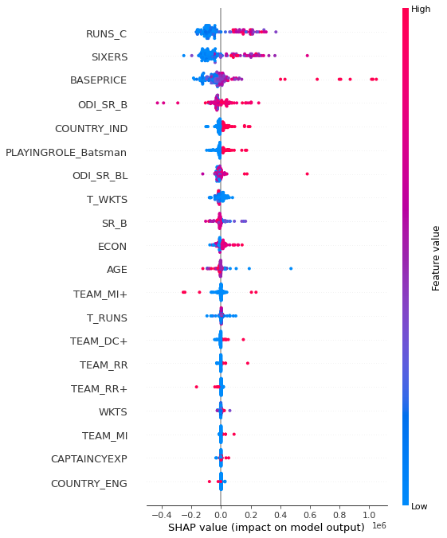

```python
import shap

exp=shap.TreeExplainer(dt_model)
shap_values=exp.shap_values(x_train)

shap.summary_plot(shap_values, x_train)
```

## Random forest regressor

```python
### Checking the "m" value of the features using random forest baseline model

forest = RandomForestRegressor()
forest.fit(x_train, y)
```

```
RandomForestRegressor()
```

##### Checking for feature importance

```python
importances=forest.feature_importances_
importances=importances.tolist()

feat_labels= x_train.columns[:]
feat_labels=feat_labels.tolist()

df_imp_rf=pd.DataFrame({'Features':feat_labels,'Importance_RF':importances}).sort_values('Importance_RF', ascending=False)
df_imp_rf['rank_RF']=df_imp_rf['Importance_RF'].rank(ascending=False)
df_imp_rf[df_imp_rf['rank_RF']<12].to_csv('rf.csv')
```

##### Checking for permutation importance on the list of features

```python
perm=PermutationImportance(forest).fit(x_train, y)
eli5.show_weights(perm, feature_names=x_train.columns.tolist())
```

| Weight | Feature |
| --- | --- |
| 0.4802 ± 0.1213 | BASEPRICE |
| 0.3267 ± 0.1564 | SIXERS |
| 0.1445 ± 0.0394 | RUNS_C |
| 0.1054 ± 0.0266 | ODI_SR_B |
| 0.0426 ± 0.0223 | AGE |
| 0.0356 ± 0.0066 | SR_B |
| 0.0320 ± 0.0059 | WKTS |
| 0.0275 ± 0.0065 | T_WKTS |
| 0.0219 ± 0.0064 | T_RUNS |
| 0.0206 ± 0.0033 | ECON |
| 0.0203 ± 0.0026 | ODI_SR_BL |
| 0.0178 ± 0.0052 | COUNTRY_IND |
| 0.0152 ± 0.0027 | TEAM_MI+ |
| 0.0135 ± 0.0021 | PLAYINGROLE_Batsman |
| 0.0042 ± 0.0024 | TEAM_DC+ |
| 0.0027 ± 0.0015 | TEAM_RR+ |
| 0.0024 ± 0.0016 | TEAM_DC |
| 0.0020 ± 0.0014 | CAPTAINCYEXP |
| 0.0020 ± 0.0004 | COUNTRY_SA |
| 0.0017 ± 0.0009 | TEAM_RR |
| *… 20 more …* |  |

##### SHAP value feature importance

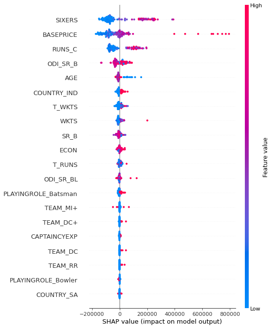

```python
import shap

exp=shap.TreeExplainer(forest)
shap_values=exp.shap_values(x_train)

shap.summary_plot(shap_values, x_train)
```

## Conclusion:

#### We are rejecting linear regression algorithm since the error distributions are very high and the R squared and adjusted R squared values are very dispersed.

#### We chose tree based algorithms and feature selection techniques like general model feature importance ranking, permutation importance ranking and SHAP value ranking since the data structure fitted the models perfectly.

##### Post that we calculated 'feature occurance count' that indicated the number of times each of the features occured in all the techniques that we applied and in the 2 models where we fitted the data.

##### Finally we chose the top 9 features (Marked in yellow in below image) that occured the most and created the top feature list that should be used for prediction

[figure not shown]